# Correlations

# Introduction

In this document, we will compute Pearson, Spearman, and Kendall correlations using real data. We will also illustrate the results with scatter plots using ggplot2.

Load Required Libraries

```r
# Load necessary libraries
library(ggplot2)
library(datasets)
```

# Load the Data

We will use the mtcars dataset, which is included in the datasets package in R. This dataset contains information about various car models.

```r
# Load the mtcars dataset
data("mtcars")

# Display the first few rows of the dataset
head(mtcars)
```

```
##                    mpg cyl disp  hp drat    wt  qsec vs am gear carb
## Mazda RX4         21.0   6  160 110 3.90 2.620 16.46  0  1    4    4
## Mazda RX4 Wag     21.0   6  160 110 3.90 2.875 17.02  0  1    4    4
## Datsun 710        22.8   4  108  93 3.85 2.320 18.61  1  1    4    1
## Hornet 4 Drive    21.4   6  258 110 3.08 3.215 19.44  1  0    3    1
## Hornet Sportabout 18.7   8  360 175 3.15 3.440 17.02  0  0    3    2
## Valiant           18.1   6  225 105 2.76 3.460 20.22  1  0    3    1
```

# Scatter Plot

First of all, plot the data! We will create a scatter plot of mpg vs wt using ggplot2 to visualize the relationship between these variables.

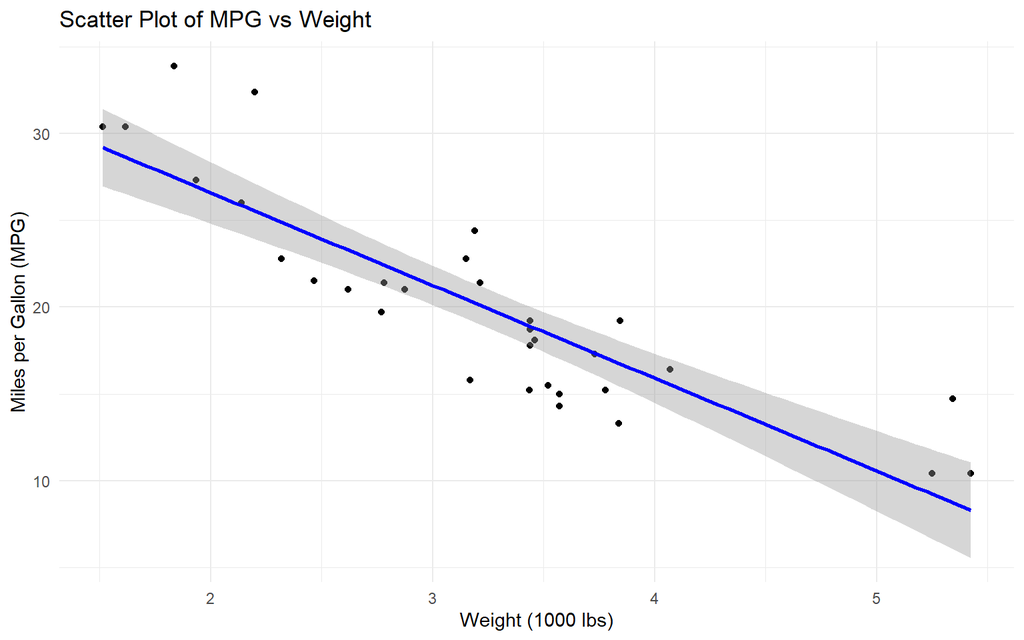

```r
# Create scatter plot
ggplot(mtcars, aes(x = wt, y = mpg)) +
  geom_point() +
  geom_smooth(method = "lm", col = "blue") +
  labs(title = "Scatter Plot of MPG vs Weight",
       x = "Weight (1000 lbs)",
       y = "Miles per Gallon (MPG)") +
  theme_minimal()
```

# Compute Correlations

We will compute the correlations between the mpg (miles per gallon) and wt (weight) variables.

# Pearson Correlation

The Pearson correlation measures the linear relationship between two variables.

```r
# Compute Pearson correlation
pearson_cor <- cor(mtcars$mpg, mtcars$wt, method = "pearson")

cat("Pearson Correlation:\n")
```

```
## Pearson Correlation:
```

```r
print(pearson_cor)
```

```
## [1] -0.8676594
```

# Spearman Correlation

The Spearman correlation measures the monotonic relationship between two variables.

```r
# Compute Spearman correlation
spearman_cor <- cor(mtcars$mpg, mtcars$wt, method = "spearman")

cat("Spearman Correlation:\n")
```

```
## Spearman Correlation:
```

```r
print(spearman_cor)
```

```
## [1] -0.886422
```

# Kendall Correlation

The Kendall correlation measures the ordinal association between two variables.

```r
# Compute Kendall correlation
kendall_cor <- cor(mtcars$mpg, mtcars$wt, method = "kendall")

cat("Kendall Correlation:\n")
```

```
## Kendall Correlation:
```

```r
print(kendall_cor)
```

```
## [1] -0.7278321
```

# Exercises

## Exercise 1: Pearson Correlation

Calculate the Pearson correlation coefficient between `mpg` (miles per gallon) and `hp` (horsepower) in the `mtcars` dataset. Display the result.

**Show Solution**

```r
# Solution
pearson_corr <- cor(mtcars$mpg, mtcars$hp, method = "pearson")
pearson_corr
```

```
## [1] -0.7761684
```

## Exercise 2: Spearman Correlation

Calculate the Spearman correlation coefficient between mpg and wt (weight) in the mtcars dataset. Display the result.

**Show Solution**

```r
# Solution
spearman_corr <- cor(mtcars$mpg, mtcars$wt, method = "spearman")
spearman_corr
```

```
## [1] -0.886422
```

## Exercise 3: Kendall Correlation

Calculate the Kendall correlation coefficient between mpg and qsec (1/4 mile time) in the mtcars dataset. Display the result.

**Show Solution**

```r
# Solution
kendall_corr <- cor(mtcars$mpg, mtcars$qsec, method = "kendall")
kendall_corr
```

```
## [1] 0.3153652
```

## Exercise 4: Scatter Plot with Correlation Line

Create a scatter plot of mpg vs hp with a Pearson correlation line using ggplot2.

**Show Solution**

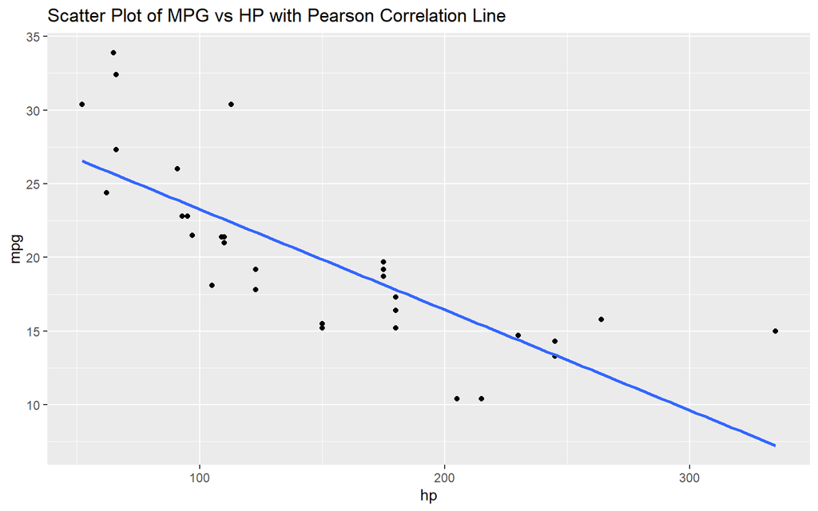

```r
# Solution
ggplot(mtcars, aes(x = hp, y = mpg)) +
  geom_point() +
  geom_smooth(method = "lm", se = FALSE) +
  labs(title = "Scatter Plot of MPG vs HP with Pearson Correlation Line")
```

# Conclusion

In this document, we computed Pearson, Spearman, and Kendall correlations using the mtcars dataset. We also illustrated the relationship between mpg and wt with a scatter plot using ggplot2. These correlations provide different perspectives on the relationship between the variables, whether it is linear, monotonic, or ordinal.